# R 통계

## 4. 연관분석

### —————————————————————————–

### 연관 분석 개념(흔히 장바구니 분석, 서열분석이라 불린다.)

1. 기업의 데이터베이스에서 상품의 구매, 서비스등 일련의 거래 또는 사건들 간의 규칙을 발견하기 위해 적용(항목은 2개 이상)
2. 손님의 장바구니에 들어있는 품목 간 관계를 알아본다는 의미에서 장바구니분석이라고 부른다.
3. 한 장바구니에 무엇이 같이 들어 있는지의 대한 분석(A를 산 다음에 B를 산다’가 연관석분석이다) 데이터가(구매 내역) 쌓이면 ’어느 고객이 어떤 제품을 같이 구매할까?’에 대한 궁금증을 해결하기 위해 연관성분석을 실시한다.(효율적인 매장 진열, 패키지 상품의 개발, 교차판매-묶음판매 전략 구성, 기획상품의 결정, 온라인 쇼핑몰에서 상품 추천 등에 응용)

측도: 연관규칙이 유용한 규칙인지 가늠하기 위해서는 지지도(support), 신뢰도(confidence), 향상도(lift) 값을 잘 보고 규칙을 선택해야 한다. 지지도 : 전체 거래 중 항목 A와 항목 B를 동시에 포함하는 거래의 비율 신뢰도 : 항목 A를 포함한 거래 중에서 A와 항목 B가 같이 포함될 비율: ‘A한 사람이 B도 하더라’ 향상도 : A가 주어지지 않았을때 품목 B의 확률에 비해 A가 주어졌을 때의 품목 B의 확률의 증가 비율 향상도 1 서로 독립(과자와 후추), >1 양의 상관관계(빵과 버터), <1 음의 상관관계(밀과 쌀)

연관 규칙의 조건 1. 연관 규칙은 “if A, then B”와 같은 형식으로 표현 2. 모든 “if A then B” 규칙은 유용한 것이 아님 3. 찾은 규칙이 유영하게 사용되기 위해서는 : 두 품목이 함께 구매한 경우 일정 수준 이상이여야 함(일정 이상의 지지도), 품목 A를 포함하는 거래 중 품목 B를 구입하는 경우의 수가 일정 수준 이상이여야 함(일정 이상의 실뢰도) : 즉 연관성 분석을 수행할때 모든 경우의 수를 분석하는 것은 불필요한 일이므로 최소 지지도를 정해 규칙을 도출한다. 처음에는 5%정도의 임의 설정해 산출해 보고 속도와 의미가 현실적인지, 규칙을 충분히 도출됐는지에 따라 지지도 조절

연관규칙분석 절차(최소 지지도를 갖는 연관규칙을 찾는 대표적인 방법 Apriori 알고리즘) 1. 최소 지지도를 정한다 2. 개별 품목 중 최소 지지도를 넘는 모든 품목을 찾는다. 3. 2에서 찾은 개별 품목만을 이용해 최소 지지도를 넘는 2가지 품목 집합을 찾는다. 4. 위의 두 절차에 찾는 품목 집합을 결합해 최소 지지도를 넘는 3가지 품목 집합을 찾는다. 5. 반복적으로 수행해 최소 지지도가 넘는 빈발품목 집합을 찾는다.

### —————————————————————————–

```r
src <- matrix(c(1, 2, 4, 5, 7, 9,
                5, 3, 2, 1, 5, 3,
                3, 4, 5, 6, 1, 2,
                4, 3, 4, 5, 6, 4,
                1, 2, 3, 3, 4, 6), ncol=6)
library(arules)
(data <- as(src, "transactions"))
```

```
## transactions in sparse format with
##  5 transactions (rows) and
##  6 items (columns)
```

```r
summary(data)
```

```
## transactions as itemMatrix in sparse format with
##  5 rows (elements/itemsets/transactions) and
##  6 columns (items) and a density of 1
##
## most frequent items:
##       1       2       3       4       5 (Other)
##       5       5       5       5       5       5
##
## element (itemset/transaction) length distribution:
## sizes
## 6
## 5
##
##    Min. 1st Qu.  Median    Mean 3rd Qu.    Max.
##       6       6       6       6       6       6
##
## includes extended item information - examples:
##   labels
## 1      1
## 2      2
## 3      3
```

```r
src <- list(c("w", "e", "g"),
            c("e", "j"),
            c("q","k", "d"),
            c("e", "d"),
            c("t", "c", "e", "r"))
names(src) <- paste("Transnumber", c(1:5), sep = "")
src
```

```
## $Transnumber1
## [1] "w" "e" "g"
##
## $Transnumber2
## [1] "e" "j"
##
## $Transnumber3
## [1] "q" "k" "d"
##
## $Transnumber4
## [1] "e" "d"
##
## $Transnumber5
## [1] "t" "c" "e" "r"
```

```r
library(arules)
data <- as(data,"transactions")
inspect(data) # 거래전표 데이터 내용을 살펴 볼 수 있다.(트랜젝션 단위로 item 데이터 보여줌)
```

```
##     items
## [1] {1,2,3,4,5,6}
## [2] {1,2,3,4,5,6}
## [3] {1,2,3,4,5,6}
## [4] {1,2,3,4,5,6}
## [5] {1,2,3,4,5,6}
```

```r
#--- 비엔나대학에서 2003년부터 2008년까지 다운로드된 ePub 전자책 관련 정보
data(Epub, package = "arules")
data <- Epub
summary(data)
```

```
## transactions as itemMatrix in sparse format with
##  15729 rows (elements/itemsets/transactions) and
##  936 columns (items) and a density of 0.001758755
##
## most frequent items:
## doc_11d doc_813 doc_4c6 doc_955 doc_698 (Other)
##     356     329     288     282     245   24393
##
## element (itemset/transaction) length distribution:
## sizes
##     1     2     3     4     5     6     7     8     9    10    11    12
## 11615  2189   854   409   198   121    93    50    42    34    26    12
##    13    14    15    16    17    18    19    20    21    22    23    24
##    10    10     6     8     6     5     8     2     2     3     2     3
##    25    26    27    28    30    34    36    38    41    43    52    58
##     4     5     1     1     1     2     1     2     1     1     1     1
##
##    Min. 1st Qu.  Median    Mean 3rd Qu.    Max.
##   1.000   1.000   1.000   1.646   2.000  58.000
##
## includes extended item information - examples:
##    labels
## 1 doc_11d
## 2 doc_13d
## 3 doc_14c
##
## includes extended transaction information - examples:
##       transactionID           TimeStamp
## 10792  session_4795 2003-01-02 10:59:00
## 10793  session_4797 2003-01-02 21:46:01
## 10794  session_479a 2003-01-03 00:50:38
```

```r
length(data)
```

```
## [1] 15729
```

```r
library(arules)
inspect(head(data))
```

```
##     items                    transactionID TimeStamp
## [1] {doc_154}                session_4795  2003-01-02 10:59:00
## [2] {doc_3d6}                session_4797  2003-01-02 21:46:01
## [3] {doc_16f}                session_479a  2003-01-03 00:50:38
## [4] {doc_11d,doc_1a7,doc_f4} session_47b7  2003-01-03 08:55:50
## [5] {doc_83}                 session_47bb  2003-01-03 11:27:44
## [6] {doc_11d}                session_47c2  2003-01-04 00:18:04
```

```r
head(as(data, "list"))
```

```
## $session_4795
## [1] "doc_154"
##
## $session_4797
## [1] "doc_3d6"
##
## $session_479a
## [1] "doc_16f"
##
## $session_47b7
## [1] "doc_11d" "doc_1a7" "doc_f4"
##
## $session_47bb
## [1] "doc_83"
##
## $session_47c2
## [1] "doc_11d"
```

```r
transactionInfo(data[size(data) > 30])  #여기서 size는 summary에서 sizes 정보 : 즉 트랜젝션에 대한 item의 갯수.
```

```
##       transactionID           TimeStamp
## 11371  session_6308 2003-08-18 07:16:12
## 13195  session_b391 2005-02-27 00:34:21
## 15319  session_fe5c 2006-04-16 01:14:28
## 1785  session_13324 2006-11-14 01:53:17
## 3867  session_17967 2007-05-22 03:00:10
## 6869  session_1d082 2008-02-26 03:26:03
## 8079  session_1f32a 2008-05-18 01:30:06
## 9236  session_21271 2008-08-18 23:57:26
## 10405 session_23930 2008-11-23 23:34:13
```

```r
library(arules)
head((year <- strftime(as.POSIXlt(transactionInfo(data)[["TimeStamp"]]), "%Y")))
```

```
## [1] "2003" "2003" "2003" "2003" "2003" "2003"
```

```r
#--- 인구사회 통계 정보
data(AdultUCI, package = "arules")
data <- AdultUCI
data[1:2, ]
```

```
##   age        workclass fnlwgt education education-num     marital-status
## 1  39        State-gov  77516 Bachelors            13      Never-married
## 2  50 Self-emp-not-inc  83311 Bachelors            13 Married-civ-spouse
##        occupation  relationship  race  sex capital-gain capital-loss
## 1    Adm-clerical Not-in-family White Male         2174            0
## 2 Exec-managerial       Husband White Male            0            0
##   hours-per-week native-country income
## 1             40  United-States  small
## 2             13  United-States  small
```

```r
data[["fnlwgt"]] <- NULL
data[["education-num"]] <- NULL
summary(data[["age"]])
```

```
##    Min. 1st Qu.  Median    Mean 3rd Qu.    Max.
##   17.00   28.00   37.00   38.64   48.00   90.00
```

```r
head(cut(data[["age"]], c(15, 37, 100)))      #--- 연령을 15, 37, 100세로 구간화
```

```
## [1] (37,100] (37,100] (37,100] (37,100] (15,37]  (15,37]
## Levels: (15,37] (37,100]
```

```r
table(cut(data[["age"]], c(15, 37, 100)))
```

```
##
##  (15,37] (37,100]
##    24974    23868
```

```r
data[["age"]] <- ordered(cut(data[["age"]], c(15, 25, 45, 65, 100)),
                         labels = c("young", "middle", "senior", "old"))
data[["hours-per-week"]] <- ordered(cut(data[["hours-per-week"]], c(0, 25, 40, 60, 168)),
                                  labels = c("part-time", "full-time", "overtime", "workaholic"))
data[["capital-gain"]] <- ordered(cut(data[["capital-gain"]], c(-Inf, 0, median(data[["capital-gain"]][data[["capital-gain"]] > 0]), Inf)),
                                  labels = c("None", "Low", "Hith"))
data[["capital-loss"]] <- ordered(cut(data[["capital-loss"]], c(-Inf, 0, median(data[["capital-loss"]][data[["capital-loss"]] > 0]), Inf)),
                                  labels = c("none", "low", "hith"))
View(data)

(data <- as(data, "transactions"))
```

```
## transactions in sparse format with
##  48842 transactions (rows) and
##  115 items (columns)
```

```r
summary(data)
```

```
## transactions as itemMatrix in sparse format with
##  48842 rows (elements/itemsets/transactions) and
##  115 columns (items) and a density of 0.1089939
##
## most frequent items:
##            capital-loss=none            capital-gain=None
##                        46560                        44807
## native-country=United-States                   race=White
##                        43832                        41762
##            workclass=Private                      (Other)
##                        33906                       401333
##
## element (itemset/transaction) length distribution:
## sizes
##     9    10    11    12    13
##    19   971  2067 15623 30162
##
##    Min. 1st Qu.  Median    Mean 3rd Qu.    Max.
##    9.00   12.00   13.00   12.53   13.00   13.00
##
## includes extended item information - examples:
##       labels variables levels
## 1  age=young       age  young
## 2 age=middle       age middle
## 3 age=senior       age senior
##
## includes extended transaction information - examples:
##   transactionID
## 1             1
## 2             2
## 3             3
```

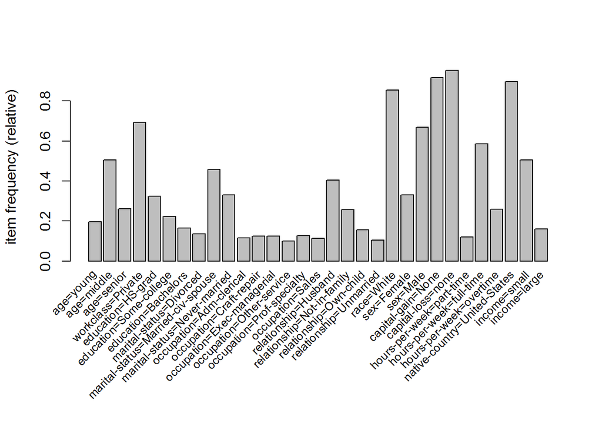

```r
library(arules)
itemFrequencyPlot(data, support = 0.1, cex.names = 0.8) #지지도가 0.1일때,즉 10%
```

```r
library(arules)
(m <- apriori(data,parameter = list (support = 0.01, confidence = 0.6)))
```

```
## Apriori
##
## Parameter specification:
##  confidence minval smax arem  aval originalSupport maxtime support minlen
##         0.6    0.1    1 none FALSE            TRUE       5    0.01      1
##  maxlen target   ext
##      10  rules FALSE
##
## Algorithmic control:
##  filter tree heap memopt load sort verbose
##     0.1 TRUE TRUE  FALSE TRUE    2    TRUE
##
## Absolute minimum support count: 488
##
## set item appearances ...[0 item(s)] done [0.00s].
## set transactions ...[115 item(s), 48842 transaction(s)] done [0.03s].
## sorting and recoding items ... [67 item(s)] done [0.01s].
## creating transaction tree ... done [0.03s].
## checking subsets of size 1 2 3 4 5 6 7 8 9 10
```

```
##  done [0.70s].
## writing ... [276443 rule(s)] done [0.05s].
## creating S4 object  ... done [0.30s].
```

```
## set of 276443 rules
```

```r
summary(m)
```

```
## set of 276443 rules
##
## rule length distribution (lhs + rhs):sizes
##     1     2     3     4     5     6     7     8     9    10
##     6   432  4981 22127 52669 75104 67198 38094 13244  2588
##
##    Min. 1st Qu.  Median    Mean 3rd Qu.    Max.
##   1.000   5.000   6.000   6.289   7.000  10.000
##
## summary of quality measures:
##     support          confidence          lift
##  Min.   :0.01001   Min.   :0.6000   Min.   : 0.7171
##  1st Qu.:0.01253   1st Qu.:0.7691   1st Qu.: 1.0100
##  Median :0.01701   Median :0.9051   Median : 1.0554
##  Mean   :0.02679   Mean   :0.8600   Mean   : 1.3109
##  3rd Qu.:0.02741   3rd Qu.:0.9542   3rd Qu.: 1.2980
##  Max.   :0.95328   Max.   :1.0000   Max.   :20.6826
##
## mining info:
##  data ntransactions support confidence
##  data         48842    0.01        0.6
```

```r
library(arules)
small <- subset(m, subset = rhs %in% "income=small" & lift > 1.2)
length(small)
```

```
## [1] 10496
```

```r
large <- subset(m, subset = rhs %in% "income=large" & lift > 1.2)
length(large)
```

```
## [1] 88
```

```r
inspect(head(sort(small, by = "confidence"), n = 3))
```

```
##     lhs                               rhs               support confidence     lift
## [1] {workclass=Private,
##      marital-status=Never-married,
##      relationship=Own-child,
##      sex=Male,
##      hours-per-week=part-time,
##      native-country=United-States} => {income=small} 0.01074895  0.7104195 1.403653
## [2] {workclass=Private,
##      marital-status=Never-married,
##      relationship=Own-child,
##      sex=Male,
##      hours-per-week=part-time}     => {income=small} 0.01144507  0.7102922 1.403402
## [3] {workclass=Private,
##      marital-status=Never-married,
##      relationship=Own-child,
##      sex=Male,
##      capital-gain=None,
##      hours-per-week=part-time,
##      native-country=United-States} => {income=small} 0.01046231  0.7097222 1.402276
```

```r
inspect(head(sort(large, by = "confidence"), n = 3))
```

```
##     lhs                                    rhs               support confidence     lift
## [1] {marital-status=Married-civ-spouse,
##      capital-gain=Hith,
##      native-country=United-States}      => {income=large} 0.01562180  0.6849192 4.266398
## [2] {marital-status=Married-civ-spouse,
##      capital-gain=Hith,
##      capital-loss=none,
##      native-country=United-States}      => {income=large} 0.01562180  0.6849192 4.266398
## [3] {relationship=Husband,
##      race=White,
##      capital-gain=Hith,
##      native-country=United-States}      => {income=large} 0.01302158  0.6846071 4.264454
```

```r
library(arules)
write(small, file="data/small.txt", sep = "\t", col.names = NA)

library("pmml")
m1 <- pmml(small)
saveXML(m1, file = "data/data.xml")
```

```
## [1] "data/data.xml"
```

```r
rm(list=ls(all=TRUE))                   #--- 작업 영역에 저장된 데이터 모두 삭제
###-----------------------------------------------------------------------------
```